# Midterm-Part1

Peter Chiu

2019/4/13

# *2020誰更能與蔡英文一較高下？分析韓國瑜與柯文哲在2018年的個人臉書粉絲專頁發文概況*

## 讀取2018/1 ~ 2019/1所有臉書發文資料

```r
library(tidyverse)
load("AllData.rda")
```

## 檢查資料狀況

```r
nrow(alldata)
```

```
## [1] 410913
```

```r
ncol(alldata)
```

```
## [1] 18
```

```r
names(alldata)
```

```
##  [1] "Date"               "Page_Name"          "Page_ID"
##  [4] "Link"               "Type"               "All_Reaction_Count"
##  [7] "LIKE_COUNT"         "WOW_COUNT"          "LOVE_COUNT"
## [10] "HAHA_COUNT"         "SAD_COUNT"          "ANGRY_COUNT"
## [13] "Comment_Count"      "Share_Count"        "Message"
## [16] "Link_Title"         "Link Description"   "created_time"
```

### 本資料檔共有18個變數，410913個觀察值。

### 這篇主要需要的變數為“Date”、“Page_Name”、“Type”、“All_Reaction_Count”、“LIKE_COUNT”、“Comment_Count”、“Share_Count”以及“Message”等。

### 基於觀察兩人的發文比較，「時間日期」因素是相當重要的，而發文的「型態」，是屬於文字、相片、還是影片也不可忽略；至於最重要的，則是發文獲得的回應，包括按讚數、各種心情表示、留言以及分享情況；而兩人發文的「內容」才是分析的重頭戲。

## 擷取兩人的粉絲專頁發文資料

```r
library(dplyr)
library(data.table)
```

```r
library(ggplot2)
```

## 擷取韓國瑜的粉絲專頁

```r
Han <- alldata %>%
  filter(Page_Name == "韓國瑜") %>%
  select(Page_Name, Page_ID, Date, All_Reaction_Count, LIKE_COUNT, WOW_COUNT, LOVE_COUNT,
         HAHA_COUNT, SAD_COUNT, ANGRY_COUNT, Comment_Count,
         Share_Count, Message, Type)
# save(Han, file="Han.rda")
```

## 擷取柯文哲的粉絲專頁

```r
Ke <- alldata %>%
  filter(Page_Name == "柯文哲") %>%
  select(Page_Name, Page_ID, Date, All_Reaction_Count, LIKE_COUNT, WOW_COUNT, LOVE_COUNT,
         HAHA_COUNT, SAD_COUNT, ANGRY_COUNT, Comment_Count,
         Share_Count, Message, Type)
# save(Ke, file="Ke.rda")
```

```r
nrow(Han)
```

```
## [1] 347
```

```r
nrow(Han)/(365+31)
```

```
## [1] 0.8762626
```

```r
nrow(Ke)
```

```
## [1] 673
```

```r
nrow(Ke)/(365+31)
```

```
## [1] 1.699495
```

### 自2018/1 ~ 2019/1的期間，韓國瑜發文數為347篇(平均每日約0.88篇)，柯文哲為673篇(平均每日約1.70篇)。

## 設定日期時間格式

```r
Han$Date=as.POSIXct(Han$Date,format = '%Y/%m/%d%H:%M:%S')
Ke$Date=as.POSIXct(Ke$Date,format = '%Y/%m/%d %H:%M:%S')
```

## 字串長度

```r
Han.mes <- nchar(Han$Message)
summary(Han.mes)
```

```
##    Min. 1st Qu.  Median    Mean 3rd Qu.    Max.    NA's
##       4      74     205     234     314    3022      18
```

```r
Ke.mes <- nchar(Ke$Message)
summary(Ke.mes)
```

```
##    Min. 1st Qu.  Median    Mean 3rd Qu.    Max.    NA's
##     2.0   101.0   323.5   317.3   483.8  3030.0     215
```

### 韓國瑜發文平均234個字，最多有3022個字，中位數為205個字。

### 柯文哲發文平均317.3個字，最多有3030個字，中位數為323.5個字。

## 分月份

```r
HanMonth <-Han%>%group_by(month=format(Date,"%Y/%m"))%>%count()%>%mutate(type="Han")
KeMonth <-Ke%>%group_by(month=format(Date,"%Y/%m"))%>%count()%>%mutate(type="Ke")

Month_rank=rbind(HanMonth, KeMonth)%>%arrange((month))
```

# **繪圖**

## *長條圖*

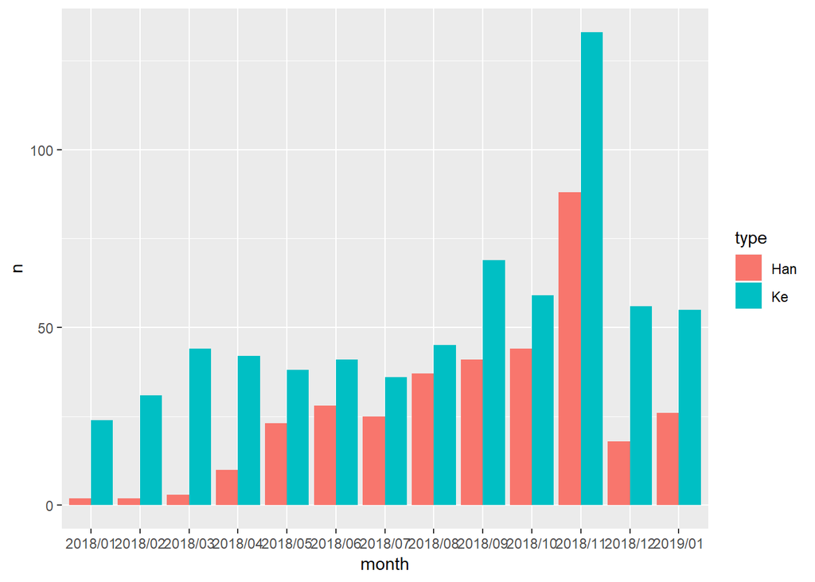

```r
ggplot(Month_rank,aes(x=month,y=n,fill=type))+
  geom_bar(stat="identity",position = "dodge")
```

## *折線圖*

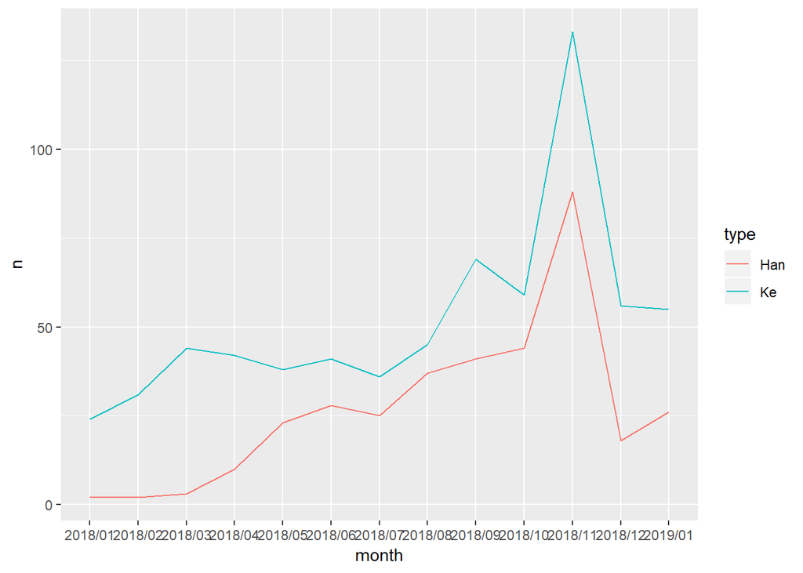

```r
ggplot(Month_rank,aes(x=month,y=n,group=type,color=type))+geom_line()
```

### 由此圖可見，柯文哲的發文次數都比韓國瑜要來得高，兩人在2018年11月時發文都明顯增加，但也是因為選舉要到了(11/24)，因此發文頻率增加是可以預期的。

### 而韓國瑜在2018年4月前發文頻率不高，但從5月開始，突然開始增加發文頻率；而柯文哲除了9月和11月發文較頻繁，其他月份也都差不多。

# **發文型態**

## 韓國瑜發文型態與獲得回應

```r
library(sjPlot)
table(Han$Type)
```

```
##
##   link  photo status  video
##     38    137     24    148
```

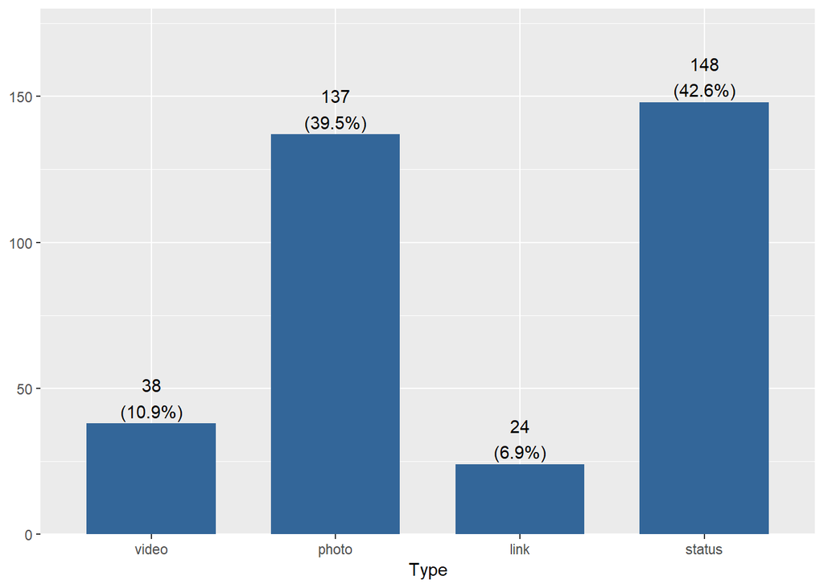

```r
sjp.frq(Han$Type, show.n = T)
```

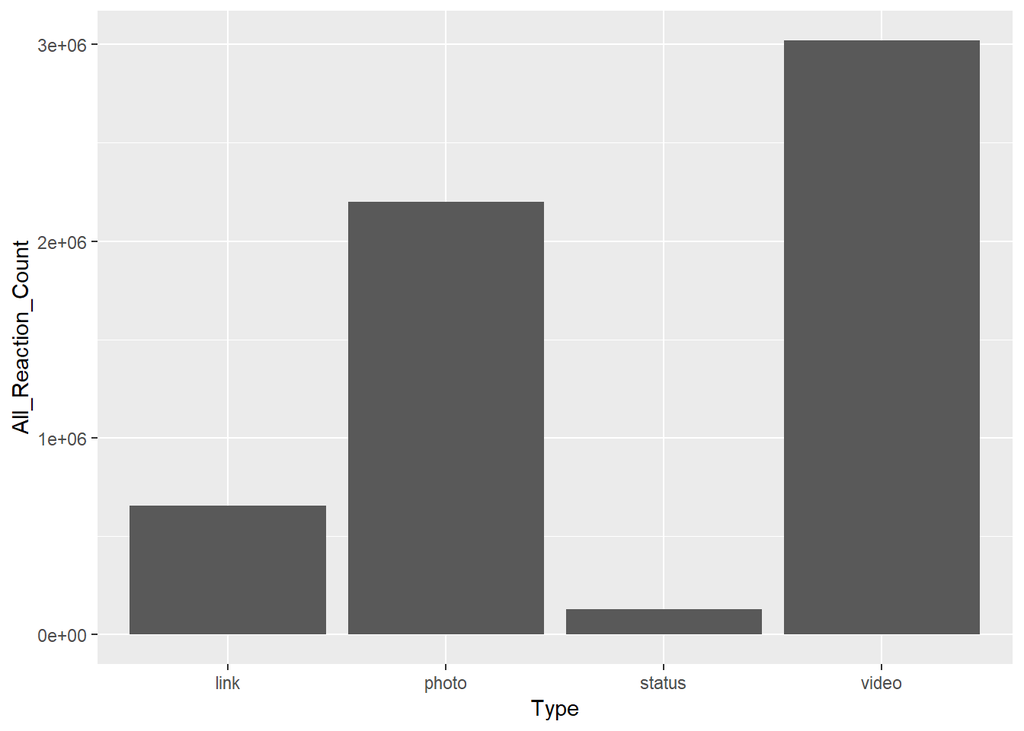

```r
ggplot() + geom_bar( data = Han,
                     aes(x=Type, y=All_Reaction_Count, group = Type),
                     stat="identity")
```

### 韓國瑜發的影片與照片數量差不多，但獲得的回應數則差距不少，而動態發文則是獲得的回應更少。

### **sjPlot底下的名稱有誤，但我不知如何修改。**

## 柯文哲發文型態與獲得回應

```r
table(Ke$Type)
```

```
##
##   link  photo status  video
##     85    231     25    332
```

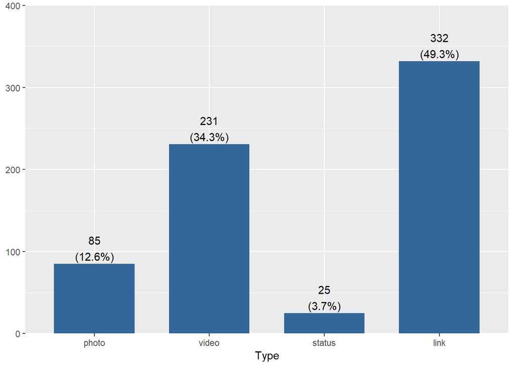

```r
sjp.frq(Ke$Type, show.n = T)
```

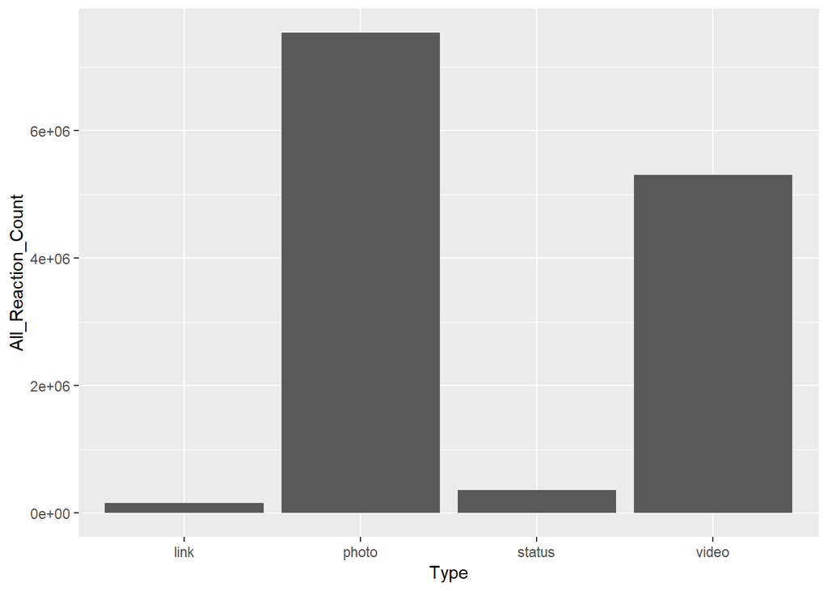

```r
ggplot() + geom_bar( data = Ke,
                     aes(x=Type, y=All_Reaction_Count, group = Type),
                     stat="identity")
```

### 這裡有個有趣的現象：柯文哲發的影片數量比照片還多很多，但照片獲得的回應數卻遠高於影片。

### 另外，柯文哲雖然也分享不少連結，但獲得的回應卻不如數量更少的動態發文。

## *觀察粉絲專頁反應與分享狀況(點狀圖)*

### 這裡我使用「分享數目」(X軸)與「所有心情數量」(Y軸)

## 韓國瑜

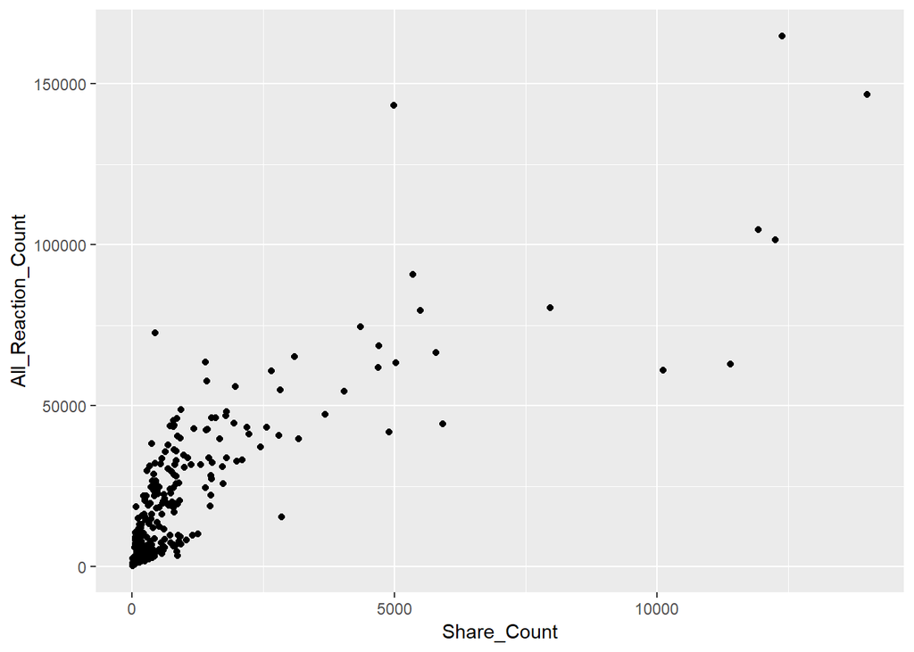

```r
ggplot(head(Han,347),aes(x=Share_Count,y=All_Reaction_Count))+
  geom_point()
```

## 柯文哲

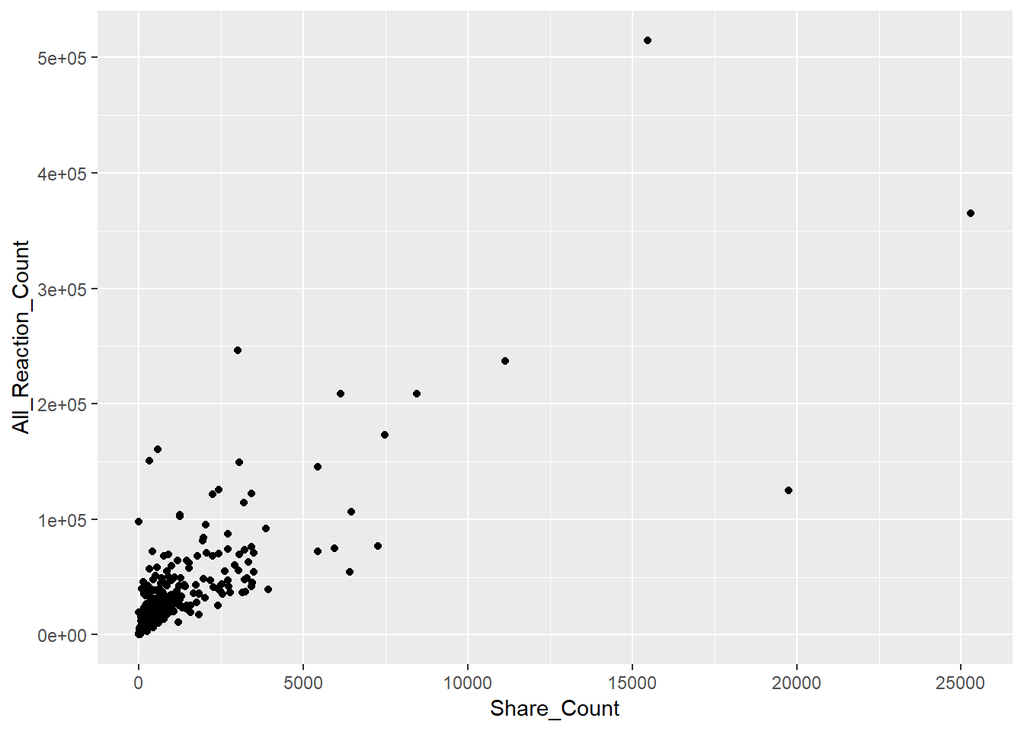

```r
ggplot(head(Ke,673),aes(x=Share_Count,y=All_Reaction_Count))+
  geom_point()
```

### 兩人獲得的反應其實差異頗大，主因韓國瑜粉絲專頁按讚人數為746301人(2019/4/13 16:37)，柯文哲粉絲專頁按讚人數則為2112062人(2019/4/13 16:38)，按讚人數較多的粉絲專頁，獲得的回應數較多也是可預期的。

## **探究韓國瑜與柯文哲的外圍粉絲團**

```r
HanGroup = filter(alldata, grepl("韓國瑜", alldata$Page_Name) == TRUE)
KeGroup = filter(alldata, grepl("柯文哲", alldata$Page_Name) == TRUE)
# save(HanGroup, file="HanG.rda")
# save(KeGroup, file="HanG.rda")
```

## 看看韓國瑜和柯文哲的個人粉絲專頁與外圍粉絲團

```r
table(HanGroup$Page_Name)
```

```
##
## 侯友宜 盧秀燕 韓國瑜 北中南連線              高雄在地韓國瑜News
##                              88                             103
##                高雄選韓國瑜News                          韓國瑜
##                             429                             347
##        韓國瑜民間粉絲團（志工團                    韓國瑜粉絲團
##                              37                             248
##                    韓國瑜新聞網
##                             284
```

```r
table(KeGroup$Page_Name)
```

```
##
##                       北美柯文哲粉絲團
##                                    235
##      台北市長挺柯文哲 大安文山挺張凱鈞
##                                      4
##                        白色力量-柯文哲
##                                      2
##         白色力量柯文哲，大安文山張凱鈞
##                                     18
## 狗王廟提告柯文哲 妨害自由罪 傷害罪證據
##                                     17
##                                 柯文哲
##                                    673
##                     柯文哲。公民顧問團
##                                      1
##                 柯文哲女性後援會粉絲團
##                                     49
##                        柯文哲市長的543
##                                     79
##                             柯文哲有病
##                                     16
##               柯文哲的玫瑰鋼鐵聖騎士團
##                                      1
```

# *畫出韓國瑜與柯文哲的發文數量以及讀者心情數量*

## 韓國瑜

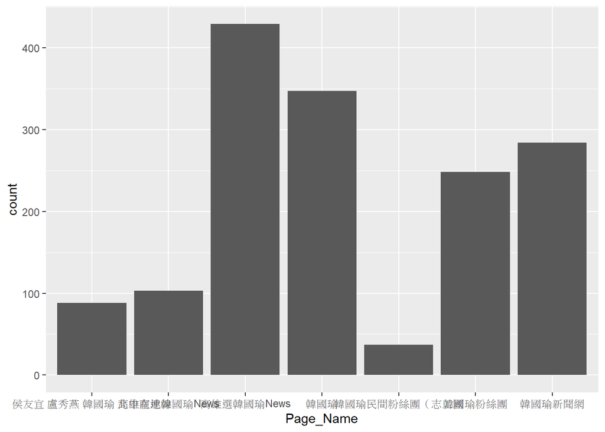

```r
library(ggplot2)
ggplot() + geom_bar(data = HanGroup, aes(x=Page_Name) )
```

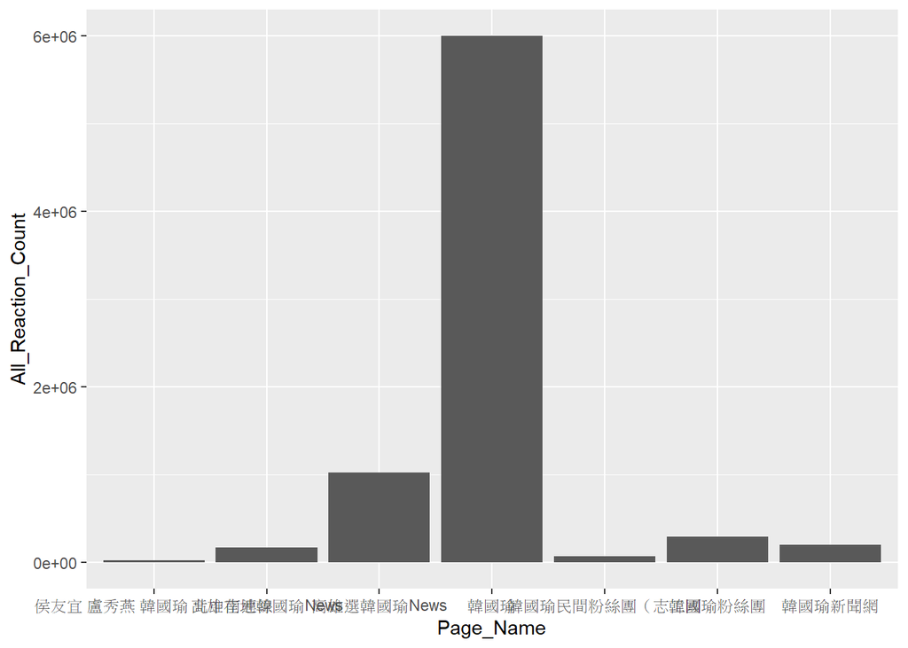

```r
ggplot() + geom_bar( data = HanGroup,
                     aes(x=Page_Name, y=All_Reaction_Count, group = Page_Name),
                     stat="identity")
```

### 韓國瑜個人的粉專是上圖中第四個

### 「高雄選韓國瑜News」發文數量比韓國瑜本人的粉專還多，不過獲得的回應當然比不上韓國瑜。

## 柯文哲

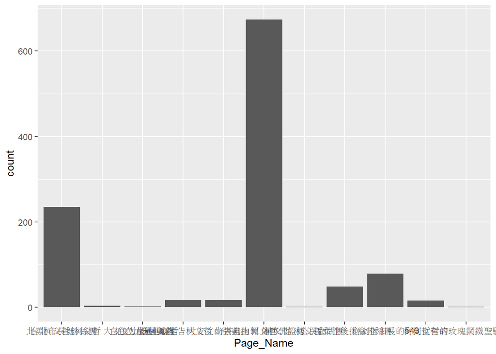

```r
ggplot() + geom_bar(data = KeGroup, aes(x=Page_Name) )
```

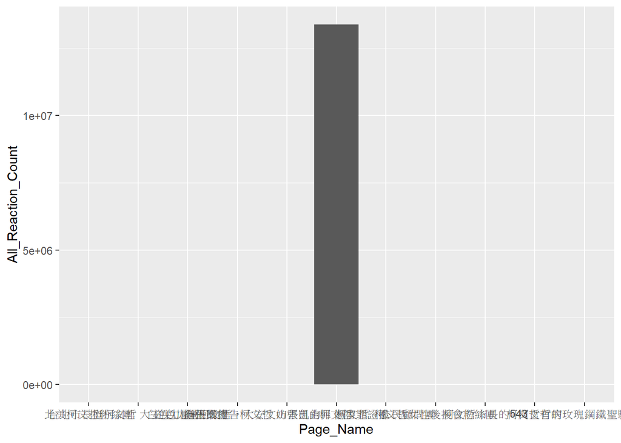

```r
ggplot() + geom_bar( data = KeGroup,
                     aes(x=Page_Name, y=All_Reaction_Count, group = Page_Name),
                     stat="identity")
```

### 柯文哲個人的粉專是上圖第六個

### 雖然柯文哲外圍的粉專有一些也發文不少，不過回應數卻是柯文哲個人粉專一枝獨秀。

## 將同一page不同發文時間的文章進行合併

```r
HanMessage = Han %>% group_by(Page_Name) %>%
  mutate(messageByName = paste0(Message, collapse = ""))
id = which(duplicated(HanMessage$Page_Name) == FALSE)
HanMessageAll = HanMessage[id,c(1,15)]
KeMessage = Ke %>% group_by(Page_Name) %>%
  mutate(messageByName = paste0(Message, collapse = ""))
id = which(duplicated(KeMessage$Page_Name) == FALSE)
KeMessageAll = KeMessage[id,c(1,15)]

# save(HanMessageAll, file="HanMA.rda")
# save(KeMessageAll, file="KeMA.rda")
```

## 初步的數量分析到此結束，文字分析請見下篇。